# Penguin Project

May and Caitlin

4/20/2020

import datasets

**Goals*** - summary stats: mean median sd interstretch interval - mean median interstretch interval/ group size x

- make a plot of the average interstretch interval per group-size x
- make a plot of the average interstretch interval per group-size per individual(*group size) x
- find slope and r2 of each of these plots, look at the trend in the data
- make histogram of interstretch intervals x
- Make a histogram of interstretch intervals per group size x
- Do shapiro- wilks test of normality x
- Do shapiro-wilks test of normality on the 1 and 2 groups x
- make a plot of the average # of observations of strething/ individual (can’t really do / observation time) x
- maaaaybe make plot of observations of stretching / individual/ observation effort with reduced data
- get slope of relationship of increase in interstretch interval / individual (les than slope of 1?)

OTHER interesting data:

- see when people were likely to observe
- see if avg stretch rate varied by time of day
- see if group size varied by time of day

Summary stats: mean stretch:

```
## [1] 132.2264
```

median_stretch:

```
## [1] 64
```

responses by group size

```
##    n_penguins stretch_mean stretch_sd stretch_median n_obs
## 1           1    272.70500   361.4757          162.0   200
## 2           2    198.54874   258.3485          108.0   636
## 3           3    158.04665   226.8575           77.5   986
## 4           4    136.23652   214.5862           68.0  1150
## 5           5    107.95697   198.8644           54.0  1255
## 6           6    123.49203   247.7682           53.0   878
## 7           7    111.83460   165.8954           50.0   659
## 8           8    101.48911   172.6994           54.0   597
## 9           9     92.78958   118.8590           53.0   499
## 10         10     98.40244   135.1804           51.5   246
## 11         11    101.95918   114.1070           59.5    98
## 12         12    147.05556   141.9295           77.5    36
##    avg_interstretch_per_individual med_interstretch_per_individual
## 1                         272.7050                           162.0
## 2                         397.0975                           216.0
## 3                         474.1400                           232.5
## 4                         544.9461                           272.0
## 5                         539.7849                           270.0
## 6                         740.9522                           318.0
## 7                         782.8422                           350.0
## 8                         811.9129                           432.0
## 9                         835.1062                           477.0
## 10                        984.0244                           515.0
## 11                       1121.5510                           654.5
## 12                       1764.6667                           930.0
```

### Inter-stretch interval by group size

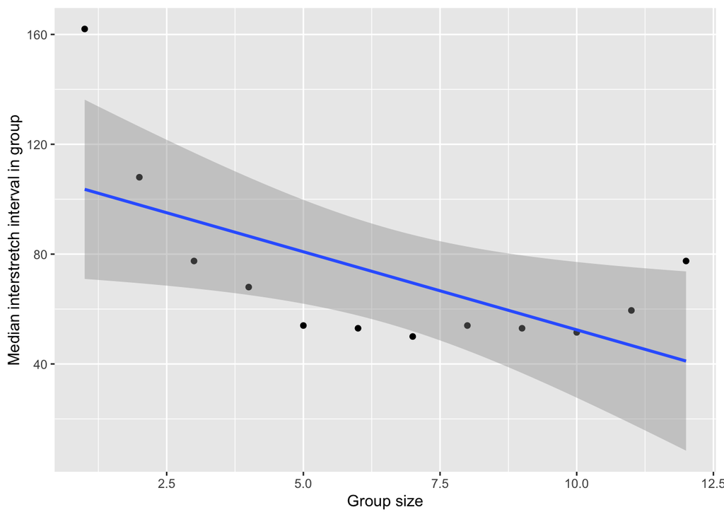

```
##
## Call:
## lm(formula = penguin_group$inter_stretch_intervals_s ~ penguin_group$n_penguins)
##
## Residuals:
##    Min     1Q Median     3Q    Max
## -185.8 -105.6  -62.0   21.3 3783.4
##
## Coefficients:
##                          Estimate Std. Error t value Pr(>|t|)
## (Intercept)               198.287      6.080   32.61   <2e-16 ***
## penguin_group$n_penguins  -12.448      1.044  -11.92   <2e-16 ***
## ---
## Signif. codes:  0 '***' 0.001 '**' 0.01 '*' 0.05 '.' 0.1 ' ' 1
##
## Residual standard error: 213.1 on 7238 degrees of freedom
## Multiple R-squared:  0.01926,    Adjusted R-squared:  0.01913
## F-statistic: 142.2 on 1 and 7238 DF,  p-value: < 2.2e-16
```

Basically, the inter-stretch interval decreases by about 12 seconds for every increase of 1 penguin in a group

But of course, if you have more penguins around, the interstretch interval will go down even if each penguin is just stretching at the same rate. So we can also account for the # of individuals around by multiplying the interstretch interval by the # of penguins around

###Interstretch interval per individual group size/ individual.

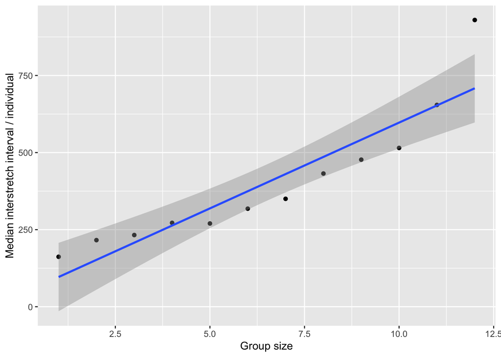

```
##
## Call:
## lm(formula = penguin_group$is_p_group ~ penguin_group$n_penguins)
##
## Residuals:
##     Min      1Q  Median      3Q     Max
## -1081.1  -485.0  -276.7    93.4 22759.0
##
## Coefficients:
##                          Estimate Std. Error t value Pr(>|t|)
## (Intercept)               224.967     30.003   7.498 7.25e-14 ***
## penguin_group$n_penguins   76.343      5.152  14.819  < 2e-16 ***
## ---
## Signif. codes:  0 '***' 0.001 '**' 0.01 '*' 0.05 '.' 0.1 ' ' 1
##
## Residual standard error: 1051 on 7238 degrees of freedom
## Multiple R-squared:  0.02945,    Adjusted R-squared:  0.02931
## F-statistic: 219.6 on 1 and 7238 DF,  p-value: < 2.2e-16
```

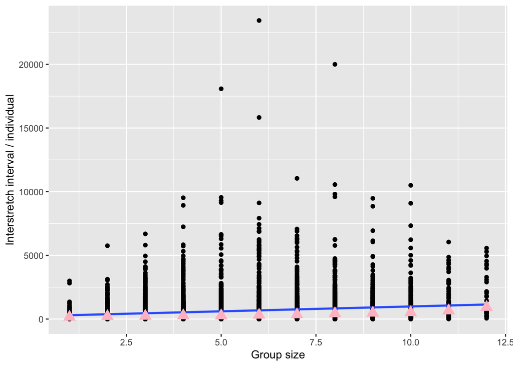

[output not shown]

## Two-sample Kolmogorov-Smirnov test

## data: penguin_subdata$Interstretch_interval_s and rpois(5000, 10)

## D = 0.8096, p-value < 2.2e-16

## alternative hypothesis: two-sided

## Shapiro-Wilk normality test

## data: penguin_subdata$Interstretch_interval_s

## W = 0.06014, p-value < 2.2e-16

[output not shown]

## # A tibble: 12 x 5

## n_penguins shapiro_statistic shapiro_p.value KStest_statistic KStest_p.value

## 1 1 0.616 6.25e-18 0.982 0

## 2 2 0.745 4.17e-25 0.958 0

## 3 3 0.626 6.65e-36 0.946 0

## 4 4 0.560 1.45e-40 0.926 0

## 5 5 0.434 1.22e-45 0.898 0

## 6 6 0.436 4.90e-40 0.886 0

## 7 7 0.619 1.54e-30 0.901 0

## 8 8 0.448 7.38e-34 0.897 0

## 9 9 0.698 2.90e-24 0.928 0

## 10 10 0.621 2.75e-19 0.925 0

## 11 11 0.760 2.80e- 9 0.923 0

## 12 12 0.785 5.19e- 4 1 0

```
This shows that all the group sizes were non-normal, including the observations with only 1 penguin in a group. Suggests that differences in group size may not account for the non-normality of the whole data set. However, groups of 1 were also not normal!



###Some other explorations

When did people observe?
Did median stretch interval change throughout the day?
Did group median size vary throughout the day?
```

## [1] “Late afternoon” “Early afternoon”

## [3] “Late morning” “Night”

## [5] “late-morning” “early afternoon”

## [7] “late afternnon” “Early morning”

## [9] “morning” “evening”

## [11] “Morning” “Afternoon”

## [13] “afternoon” NA

## [15] “moring” “Late morning- Mehrdad”

## [17] “Late morning/Early afternoon”

## # A tibble: 5 x 4

## Time_of_day number_observations median_intervals median_groupsize

## 1 Early afternoon 1163 84.0 4

## 2 Early morning 548 57.0 7

## 3 Late afternoon 1637 69. 5

## 4 Late morning 1473 52. 5

## 5 Night 1468 59. 5

```

Plot of when people observed:

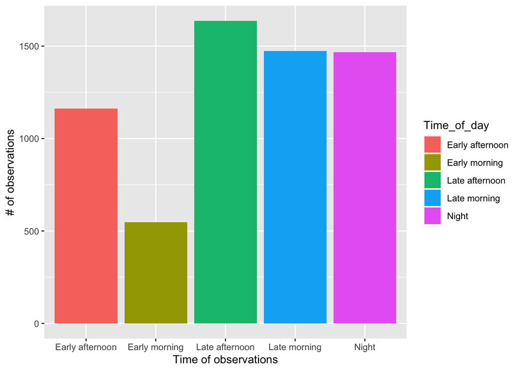

Plot of group size by time of day

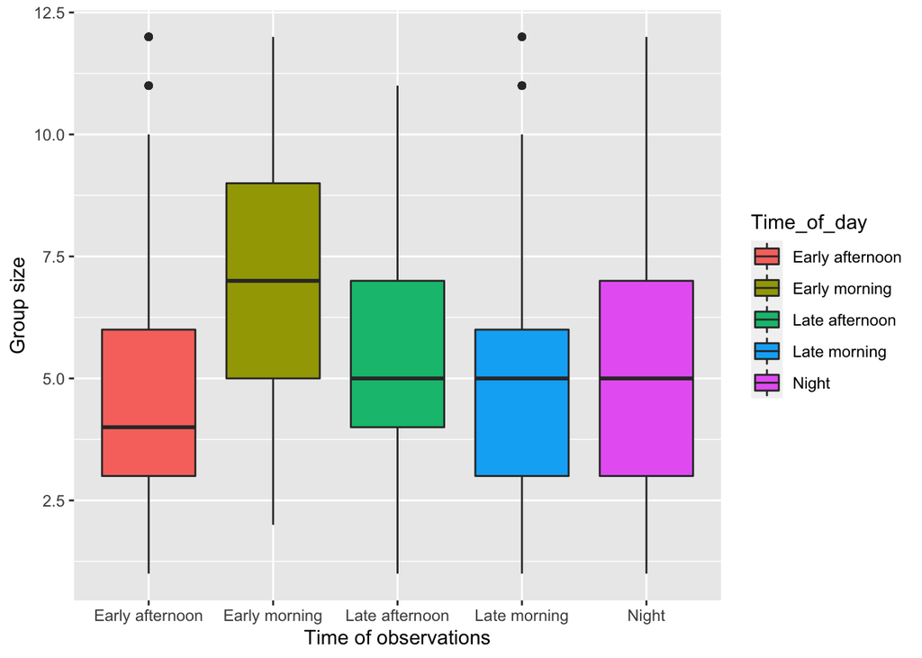